# Assignment_1

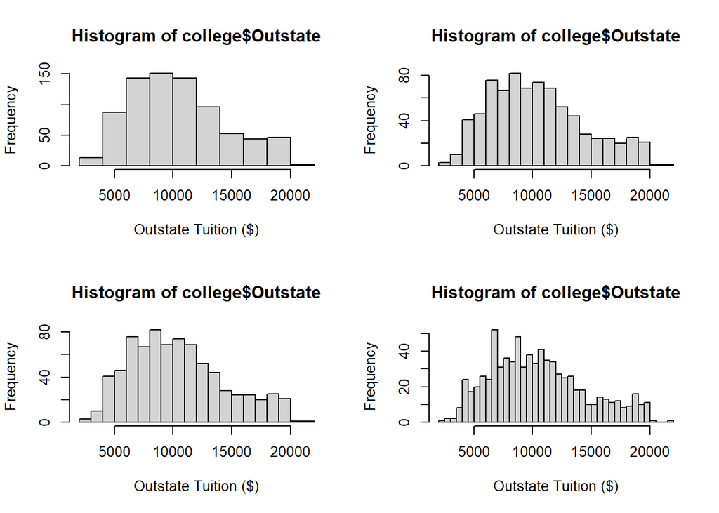

```r
par(mfrow = c(2,2))
xlab = "Outstate Tuition ($)"
hist(college$Outstate, xlab = xlab)
hist(college$Outstate,breaks = 15, xlab = xlab)
hist(college$Outstate,breaks = 20, xlab = xlab)
hist(college$Outstate,breaks = 50, xlab = xlab)
```

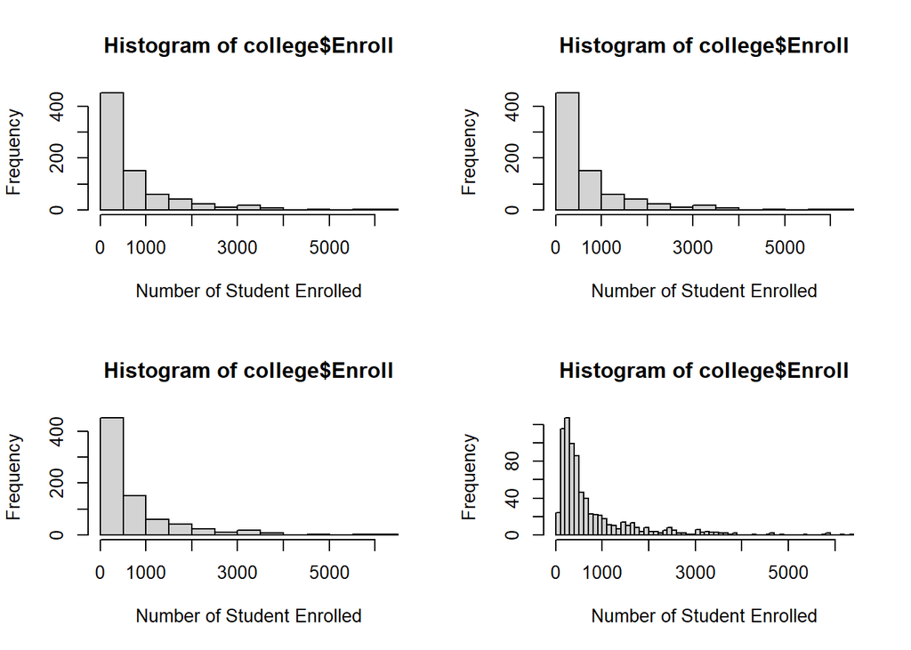

```r
par(mfrow = c(2,2))
xlab = "Number of Student Enrolled"
hist(college$Enroll, xlab = xlab)
hist(college$Enroll,breaks = 15, xlab = xlab)
hist(college$Enroll,breaks = 20, xlab = xlab)
hist(college$Enroll,breaks = 50, xlab = xlab)
```

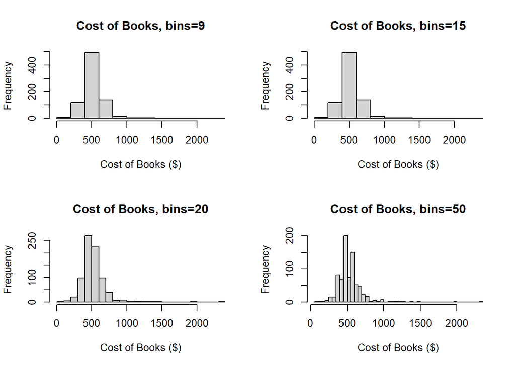

```r
par(mfrow = c(2,2))
xlab = "Cost of Books ($)"
hist(college$Books, xlab = xlab,main = 'Cost of Books, bins=9')
hist(college$Books,breaks = 15, xlab = xlab, main = 'Cost of Books, bins=15')
hist(college$Books,breaks = 20, xlab = xlab,main = 'Cost of Books, bins=20')
hist(college$Books,breaks = 50, xlab = xlab,main = 'Cost of Books, bins=50')
```

Continue to explore the data:

9. This exercise involves the Auto data set studied in the lab. Make sure that the missing values have been removed from the data.

```r
auto <- ISLR::Auto
summary(auto)
```

```
##       mpg          cylinders      displacement     horsepower        weight
##  Min.   : 9.00   Min.   :3.000   Min.   : 68.0   Min.   : 46.0   Min.   :1613
##  1st Qu.:17.00   1st Qu.:4.000   1st Qu.:105.0   1st Qu.: 75.0   1st Qu.:2225
##  Median :22.75   Median :4.000   Median :151.0   Median : 93.5   Median :2804
##  Mean   :23.45   Mean   :5.472   Mean   :194.4   Mean   :104.5   Mean   :2978
##  3rd Qu.:29.00   3rd Qu.:8.000   3rd Qu.:275.8   3rd Qu.:126.0   3rd Qu.:3615
##  Max.   :46.60   Max.   :8.000   Max.   :455.0   Max.   :230.0   Max.   :5140
##
##   acceleration        year           origin                      name
##  Min.   : 8.00   Min.   :70.00   Min.   :1.000   amc matador       :  5
##  1st Qu.:13.78   1st Qu.:73.00   1st Qu.:1.000   ford pinto        :  5
##  Median :15.50   Median :76.00   Median :1.000   toyota corolla    :  5
##  Mean   :15.54   Mean   :75.98   Mean   :1.577   amc gremlin       :  4
##  3rd Qu.:17.02   3rd Qu.:79.00   3rd Qu.:2.000   amc hornet        :  4
##  Max.   :24.80   Max.   :82.00   Max.   :3.000   chevrolet chevette:  4
##                                                  (Other)           :365
```

There are no missing values in this dataset

1. Which of the predictors are quantitative, and which are qualitative?

Quantitative: mpg, displacement, horsepower, weight, acceleration Qualitative: cylinders, origin, year, name

2. What is the range of each quantitative predictor? You can answer this using the range() function.

```r
range(auto$mpg)
```

```
## [1]  9.0 46.6
```

```r
range(auto$displacement)
```

```
## [1]  68 455
```

```r
range(auto$horsepower)
```

```
## [1]  46 230
```

```r
range(auto$weight)
```

```
## [1] 1613 5140
```

```r
range(auto$acceleration)
```

```
## [1]  8.0 24.8
```